# Rプログラミング入門 記述統計量とデータ可視化（1）

Cho（ztempest0218@gmail.com）

Last Updated: 2026-06-07

**今回の内容**

- 記述統計とは
  - `summary()` と `dplyr` による要約
- データ可視化
  - `ggplot2` の文法
  - 主要なグラフ

**今回使用するデータ**

- ssdse_clean_sample_2018_2023.rds

このデータは、SSDSE（教育用標準データセット）から授業用に必要な変数だけを取り出し、変数名をわかりやすく整理した小サンプルである。今回は、日本の都道府県別データを用いて、記述統計量とデータ可視化を学ぶ。

# 1 記述統計とは

データ分析の最初の作業は、いきなり回帰分析や機械学習を行うことではない。まず、データがどのような特徴を持っているのかを確認する必要がある。この作業を **記述統計**（descriptive statistics）という。

記述統計量とは、データの特徴を少数の数字で要約したものである。例えば、都道府県別の人口データがある場合、47都道府県の人口を一つ一つ見るよりも、平均値、中央値、標準偏差、最小値、最大値などを見る方が全体像を把握しやすい。

| 記述統計量 | 意味 |
| --- | --- |
| 平均値（mean） | データの代表的な水準 |
| 標準偏差（standard deviation） | データのばらつき |
| 中央値（median） | データを小さい順に並べたときの真ん中 |
| 最小値（min） | 最も小さい値 |
| 最大値（max） | 最も大きい値 |
| 四分位数（quartile） | データを4つに分ける境界 |

記述統計表では、欠損値（missing value）は平均値や標準偏差の計算に含めず、観察されている値だけを用いて計算することが一般的である。そのため、表に示される `N` は、その変数について欠損していない観測値の数を意味する。前処理において、欠損値の確認は重要である。

ただし、記述統計量だけではデータの形を完全には理解できない。同じ平均値を持つデータであっても、一部の地域だけが極端に大きい場合もあれば、全体的に似た値を持つ場合もある。そのため、記述統計量とデータ可視化をセットで使うことが重要である。

ここから、授業用に整理した小サンプルデータを読み込む。`tidyverse` には、データ前処理の `dplyr`、データ可視化の `ggplot2`、データ変形の `tidyr` などが含まれている。`tidyverse`を一括に読み込むため、単独で `dplyr`、`ggplot2`や `tidyr` を読み込む必要がなくなる。

```r
rm(list = ls())

# 初回のみインストール
# install.packages("tidyverse")

library(tidyverse)
japan <- readRDS("./data/ssdse_clean_sample_2018_2023.rds")
```

このデータは、2018年から2023年までの47都道府県データであり、282行、34列から構成されている。都道府県・年ごとに、人口、結婚、出生、人口移動、保育、経済関連指標などの変数が含まれている。

主な変数の意味は以下の通りである。

| 変数名 | 意味 |
| --- | --- |
| `year` | 年度 |
| `prefecture` | 都道府県 |
| `child_share` | 15歳未満人口割合 |
| `total_fertility_rate` | 合計特殊出生率 |
| `births_per_1000` | 千人あたり出生数 |
| `marriages_per_1000` | 千人あたり婚姻件数 |
| `net_migration_per_1000` | 千人あたり純転入者数 |
| `waiting_children_per_1000_nursery_children` | 保育所等在所児千人あたり待機児童数 |
| `childcare_workers_per_1000_nursery_children` | 保育所等在所児千人あたり保育士数 |
| `household_consumption` | 消費支出（二人以上の世帯） |
| `residential_land_price` | 住宅地平均価格 |

## 1.1 `summary()` による要約

R で最も簡単に記述統計量を確認する方法は、Base R の `summary()` 関数を使うことである。

```r
summary(japan)
```

ただし、データフレーム全体を `summary()` に入れると、そのデータに含まれるすべての変数について記述統計量が出力される。変数が多いデータでは出力が長くなるため、必要な変数だけを選んで確認する方がよい。

ここでは、少子化に関する変数だけを取り出し、`low_birth` というオブジェクトを作成する。

```r
low_birth <- japan %>%
  select(
    year,
    prefecture,
    child_share,
    births_per_1000,
    marriages_per_1000,
    total_fertility_rate,
    net_migration_per_1000
  )

summary(low_birth)
```

```
##       year          prefecture   child_share      births_per_1000
##  Min.   :2018   Length   :282   Min.   :0.09081   Min.   : 3.951
##  1st Qu.:2019   N.unique : 47   1st Qu.:0.11243   1st Qu.: 5.904
##  Median :2020   N.blank  :  0   Median :0.11768   Median : 6.371
##  Mean   :2020   Min.nchar:  3   Mean   :0.11884   Mean   : 6.434
##  3rd Qu.:2022   Max.nchar:  4   3rd Qu.:0.12355   3rd Qu.: 6.907
##  Max.   :2023                   Max.   :0.16988   Max.   :10.820
##  marriages_per_1000 total_fertility_rate net_migration_per_1000
##  Min.   :2.519      Min.   :0.990        Min.   :-5.2901
##  1st Qu.:3.516      1st Qu.:1.300        1st Qu.:-2.8954
##  Median :3.817      Median :1.405        Median :-1.8770
##  Mean   :3.890      Mean   :1.405        Mean   :-1.5457
##  3rd Qu.:4.245      3rd Qu.:1.500        3rd Qu.:-0.7008
##  Max.   :6.144      Max.   :1.890        Max.   : 6.1808
```

`summary()` は、データの全体像を素早く確認するために便利である。一方、レポートや論文に載せる表としては、そのままでは読みにくいことが多い。

## 1.2 `dplyr` による記述統計量

より自由に記述統計量を計算したい場合は、`dplyr` の `summarise()` を使う。ここでは、データ全体について人口の記述統計量を計算する。

```r
japan %>%
  summarise(
    n = n(),
    mean_pop = mean(population),
    median_pop = median(population),
    sd_pop = sd(population),
    min_pop = min(population),
    max_pop = max(population)
  )
```

| n | mean_pop | median_pop | sd_pop | min_pop | max_pop |
| --- | --- | --- | --- | --- | --- |
| 282 | 2674639 | 1582128 | 2766150 | 537000 | 14086000 |

主な関数は以下の通りである。

| 関数 | 意味 |
| --- | --- |
| `n()` | 行数を数える |
| `mean()` | 平均値 |
| `median()` | 中央値 |
| `sd()` | 標準偏差 |
| `min()` | 最小値 |
| `max()` | 最大値 |

グループごとに要約したい場合は、`group_by()` を使う。例えば、年ごとに平均婚姻件数、平均合計特殊出生数、平均純転入者数を確認してみよう。

```r
japan %>%
  group_by(year) %>%
  summarise(
    n = n(),
    mean_marriage = mean(marriages_per_1000),
    mean_net_migration = mean(net_migration_per_1000),
    mean_tfr = mean(total_fertility_rate)
  ) %>%
  mutate(across(where(is.numeric), ~ round(., 2))) %>%
  as.data.frame()
```

| year | n | mean_marriage | mean_net_migration | mean_tfr |
| --- | --- | --- | --- | --- |
| 2018 | 47 | 4.27 | -1.80 | 1.50 |
| 2019 | 47 | 4.35 | -1.97 | 1.45 |
| 2020 | 47 | 3.87 | -1.44 | 1.42 |
| 2021 | 47 | 3.71 | -1.08 | 1.40 |
| 2022 | 47 | 3.68 | -1.31 | 1.36 |
| 2023 | 47 | 3.46 | -1.68 | 1.29 |

同じように、都道府県ごとに要約することもできる。ここでは、全期間の平均出生数が低い都道府県を確認してみよう。

```r
japan %>%
  group_by(prefecture) %>%
  summarise(
    n = n(),
    mean_marriage = mean(marriages_per_1000),
    mean_net_migration = mean(net_migration_per_1000),
    mean_tfr = mean(total_fertility_rate)
  ) %>%
  # 合計特殊出生率昇順
  arrange(mean_tfr) %>%
  mutate(across(where(is.numeric), ~ round(., 2))) %>%
  as.data.frame()
```

| prefecture | n | mean_marriage | mean_net_migration | mean_tfr |
| --- | --- | --- | --- | --- |
| 東京都 | 6 | 5.47 | 3.70 | 1.10 |
| 宮城県 | 6 | 3.94 | -0.35 | 1.17 |
| 北海道 | 6 | 3.92 | -0.94 | 1.18 |
| 京都府 | 6 | 3.95 | -1.36 | 1.22 |
| 神奈川県 | 6 | 4.47 | 2.55 | 1.23 |
| 秋田県 | 6 | 2.85 | -3.63 | 1.23 |
| 埼玉県 | 6 | 4.10 | 2.56 | 1.23 |
| 千葉県 | 6 | 4.10 | 2.77 | 1.24 |
| 大阪府 | 6 | 4.72 | 1.05 | 1.27 |
| 奈良県 | 6 | 3.50 | -2.06 | 1.29 |

[output cut: 37 more lines]

一般向けの説明や、平均値を用いて傾向を簡単に確認するレポートであれば、ここまでの要約で十分である。一方、レポートや論文で記述統計量を表として示す場合は、平均値と標準偏差を整理した表を作ることが多い。

## 1.3 学術論文でよく使う記述統計表

最後に、学術論文やレポートでそのまま使いやすい記述統計表を作成する。統計ソフト Stata では、`outreg2` パッケージを用いることで、推定結果や記述統計量を比較的簡単に整った形式で出力できる。一方で、Rでは表をきれいに出力するために、外部パッケージや自作関数を組み合わせて使うことが多い。ここでは `modelsummary` パッケージを使う。

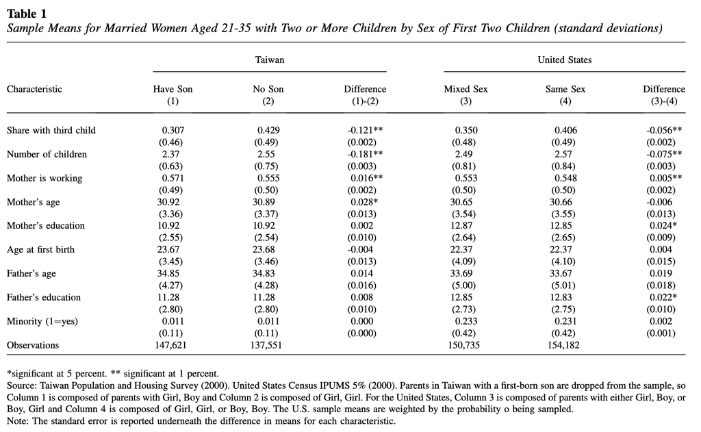

When is the Local Average Treatment Close to the Average? Avraham Ebenstein Journal of Human Resources Oct 2009, 44 (4) 955-975; DOI: 10.3368/jhr.44.4.955

```r
# install.packages("modelsummary")
library(modelsummary)

# 自作関数（上段平均、下段標準偏差）
mean_sd <- function(x) {
  sprintf(
    "%.3f\n(%.3f)", #小数点3位まで、\n改行
    mean(x, na.rm = TRUE),
    sd(x, na.rm = TRUE)
  )
}

# 自作関数（グループごとに観測値を数える）
make_n_row <- function(data, group_var, label = "N") {
  data %>%
    count({{ group_var }}) %>%
    mutate(n = as.character(n)) %>%
    pivot_wider(
      names_from = {{ group_var }},
      values_from = n
    ) %>%
    cbind(
      data.frame(" " = label, check.names = FALSE),
      .
    )
}

# Nを保存（年ごとに）
n_row <- make_n_row(japan, year)

# 変数リスト~ Factor(year) * mean_sd
# 最後はグループと統計量を指定
desc_formula <-
  (`15歳未満人口割合` = child_share) +
  (`千人あたり出生数` = births_per_1000) +
  (`千人あたり婚姻件数` = marriages_per_1000) +
  (`合計特殊出生率` = total_fertility_rate) +
  (`千人あたり純転入者数` = net_migration_per_1000) +
  (`在所児千人あたり待機児童数` = waiting_children_per_1000_nursery_children) +
  (`在所児千人あたり保育士数` = childcare_workers_per_1000_nursery_children) +
  (`消費支出（千円）` = household_consumption / 1000) +
  (`住宅地平均価格（千円）` = residential_land_price / 1000) ~ Factor(year) * mean_sd

# Output
datasummary(
  desc_formula,
  data = japan,
  add_rows = n_row,
  title = "Table 1 記述統計量",
  notes = "Note: 括弧内は標準偏差を示す。",
  escape = FALSE,
  # output = "descriptive_statistics.png"
)
```

Table 1 記述統計量

|  | 2018 | 2019 | 2020 | 2021 | 2022 | 2023 |
| --- | --- | --- | --- | --- | --- | --- |
| 15歳未満人口割合 | 0.123 (0.011) | 0.121 (0.011) | 0.119 (0.010) | 0.119 (0.011) | 0.117 (0.011) | 0.115 (0.011) |
| 千人あたり出生数 | 7.126 (0.832) | 6.721 (0.790) | 6.549 (0.814) | 6.392 (0.796) | 6.092 (0.763) | 5.726 (0.704) |
| 千人あたり婚姻件数 | 4.274 (0.481) | 4.352 (0.503) | 3.870 (0.437) | 3.714 (0.409) | 3.676 (0.465) | 3.457 (0.449) |
| 合計特殊出生率 | 1.503 (0.138) | 1.455 (0.141) | 1.421 (0.137) | 1.400 (0.146) | 1.358 (0.149) | 1.293 (0.133) |
| 千人あたり純転入者数 | -1.800 (2.114) | -1.972 (2.247) | -1.435 (1.797) | -1.084 (1.633) | -1.305 (1.764) | -1.678 (2.007) |
| 在所児千人あたり待機児童数 | 5.533 (7.503) | 4.977 (6.242) | 3.533 (5.024) | 1.546 (2.190) | 0.951 (1.445) | 1.288 (2.122) |
| 在所児千人あたり保育士数 | 126.116 (23.048) | 124.528 (24.604) | 120.755 (25.762) | 117.205 (27.092) | 123.152 (29.317) | 176.227 (18.998) |
| 消費支出（千円） | 288.163 (24.894) | 288.525 (26.260) | 279.688 (22.605) | 281.003 (23.489) | 289.630 (19.187) | 295.856 (24.144) |
| 住宅地平均価格（千円） | 51.072 (57.197) | 52.051 (59.759) | 52.317 (60.238) | 52.645 (60.724) | 53.372 (61.992) | 54.638 (64.366) |
| N | 47 | 47 | 47 | 47 | 47 | 47 |

Note: 括弧内は標準偏差を示す。

この表では、各セルの上段が平均値であり、下段の括弧内が標準偏差である。各年は47都道府県から構成されるため、各年の観測数は47である。

注:学術論文では $\LaTeX$ が標準的に用いられているが、R入門の授業では展開しない。関心のある方(大学院に進学する方)は、各自で学習すること。

# 2 データ可視化

データ可視化とは、データをグラフとして表現し、パターンや関係を視覚的に理解することである。例えば、都道府県犯罪率は平均値だけを見ると実感しにくいが、ヒートマップで一部の地域に犯罪が集中していることがすぐにわかる。

データ可視化で重要なのは、きれいな図を作ることだけではない。むしろ、次の点を意識する必要がある。

- **何を比較したいのか**
- **どの変数を使うのか**
- **1行が何を表しているのか**
- **数値変数なのか、カテゴリ変数なのか**
- **図を見る人に何を伝えたいのか**

多くの読者は、50ページを超える論文やレポートを最初から最後まで丁寧に読む時間を持っていない。これは一般の読者だけでなく、研究者にも当てはまる。実際には、まず図表を見て、その論文が何を示しているのかを大まかに把握することが多い。新聞、テレビ、ウェブ記事などの一般メディアでは、この傾向はさらに強い。適切に作られた図は、長い文章で説明するよりも、はるかに短い時間で多くの情報を伝えることができる。場合によっては、数十行、あるいは数百行の文章に相当する内容を、一つの図で直感的に示すこともできる。したがって、図を作成する目的は、単に見た目を整えることではない。データの特徴を見つけ、比較を容易にし、読者に重要なメッセージを伝えることである。

R でデータ可視化を行う代表的なパッケージが `ggplot2` である。`ggplot2`の特徴として、

- グラフを**層**として積み重ねて作成できる、dplyr のパイプ処理と似ており、考えながら図を作れる。
- 散布図、棒グラフ、折れ線、箱ひげ図などを**統一的な文法**で作成できる。
- 美的センスのない人もきれいな図を作成できる。

## 2.1 `ggplot2` の文法

`ggplot2`の基本形は次の通りである。

```r
ggplot(data = データ名, aes(x = 横軸の変数, y = 縦軸の変数)) +
  geom_グラフの種類()
```

`ggplot2` では、まず `ggplot()` で使用するデータと変数を指定し、その後に `geom_*()` を追加してグラフの種類を指定する。

| 引数 | 意味 |
| --- | --- |
| `data` | 使用するデータ |
| `aes()` | 変数と見た目の対応関係 |
| `x` | 横軸 |
| `y` | 縦軸 |
| `geom_point()` | 散布図 |
| `geom_line()` | 折れ線グラフ |
| `geom_col()` | 棒グラフ |
| `geom_histogram()` | ヒストグラム |
| `geom_boxplot()` | 箱ひげ図 |

ここからは、横断面の比較をしやすくするために、2023年のデータを取り出し、都道府県を大まかな地域に分類しておく。

```r
japan_2023 <- japan %>%
  filter(year == 2023) %>%
  mutate(
    region = case_when(
      prefecture %in% c("北海道") ~ "北海道",
      prefecture %in% c("青森県", "岩手県", "宮城県", "秋田県", "山形県", "福島県") ~ "東北",
      prefecture %in% c("茨城県", "栃木県", "群馬県", "埼玉県", "千葉県", "東京都", "神奈川県") ~ "関東",
      prefecture %in% c("新潟県", "富山県", "石川県", "福井県", "山梨県", "長野県", "岐阜県", "静岡県", "愛知県") ~ "中部",
      prefecture %in% c("三重県", "滋賀県", "京都府", "大阪府", "兵庫県", "奈良県", "和歌山県") ~ "近畿",
      prefecture %in% c("鳥取県", "島根県", "岡山県", "広島県", "山口県") ~ "中国",
      prefecture %in% c("徳島県", "香川県", "愛媛県", "高知県") ~ "四国",
      prefecture %in% c("福岡県", "佐賀県", "長崎県", "熊本県", "大分県", "宮崎県", "鹿児島県", "沖縄県") ~ "九州・沖縄",
      TRUE ~ "その他"
    )
  )
```

図において日本語の文字化けを生じないように、日本語フォントを設定する。

```r
# 初回showtextをインストール、https://fonts.google.com/を確認
library(showtext)
font_add_google("Noto Serif JP", "notojp")
showtext_auto()
```

## 2.2 散布図

散布図は、2つの数値変数の関係を見るためのグラフである。例えば、婚姻件数と出生数との関係を確認してみよう。

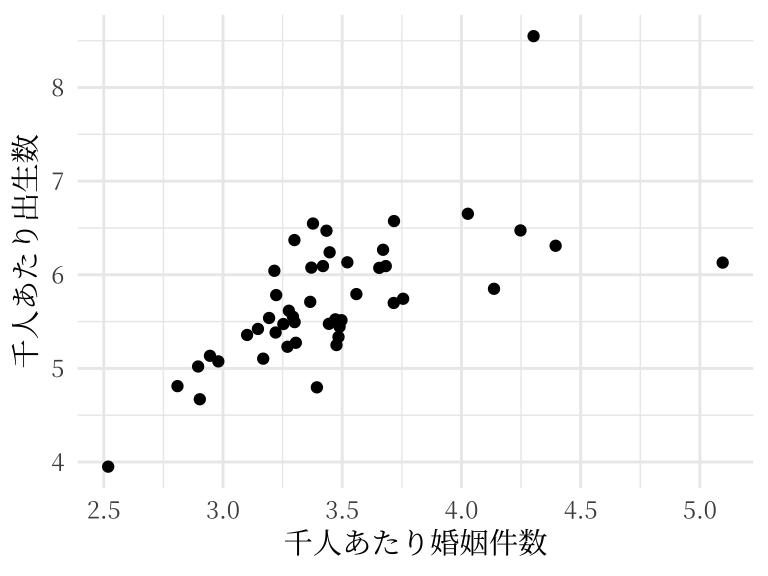

```r
ggplot(
  data = japan_2023,
  aes(
    x = marriages_per_1000,
    y = births_per_1000
  )
) +
  geom_point() +
  labs(
    x = "千人あたり婚姻件数",
    y = "千人あたり出生数"
  ) +
  theme_minimal(base_family = "notojp")
```

横軸は千人あたり婚姻件数、縦軸は千人あたり出生数である。右上がりの傾向が見える場合、婚姻件数が多い地域ほど出生数も多い傾向があると考えられる。

### 2.2.1 色を追加する

`aes()` の中で `color` を指定すると、カテゴリごとに色を変えることができる。

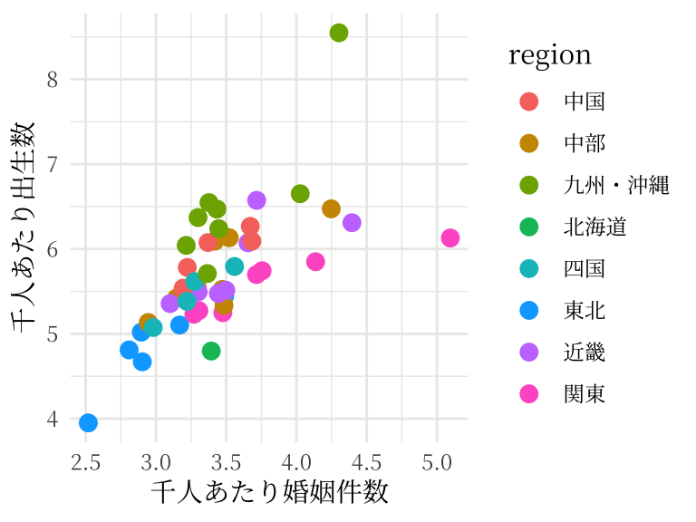

```r
ggplot(
  japan_2023,
  aes(
    x = marriages_per_1000,
    y = births_per_1000,
    color = region # regionごとに色をつける
  )
) +
  geom_point(size = 3) +
  labs(
    x = "千人あたり婚姻件数",
    y = "千人あたり出生数"
  ) +
  theme_minimal(base_family = "notojp")
```

ここでは、地域ごとに点の色を変えている。同じ散布図でも、地域情報を加えると、どの地域がどのあたりに位置しているかを確認しやすくなる。例えば、東北地方では婚姻件数も出生数も全体的に低いレベルである。また、関東地方では、（比較的に）婚姻件数が多いが、出生数が少ない。

### 2.2.2 ラベルを追加する

都道府県名を表示したい場合は、`geom_text_repel()` を使うことができる。ただし、すべての点にラベルを付けると読みにくくなることがある。ラベルは、重要な点や外れ値だけに付ける方が読みやすい。

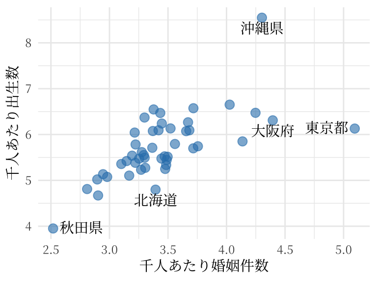

```r
#install.packages("ggrepel")
library(ggrepel)

ggplot(
  data = japan_2023,
  aes(
    x = marriages_per_1000,
    y = births_per_1000
  )
) +
  geom_point(
    size = 3,
    color = "#2C7FB8",
    alpha = 0.6 # 透明
  ) +
  geom_text_repel(
    data = japan_2023 %>%
    filter(prefecture %in% c("東京都", "大阪府", "北海道", "沖縄県", "秋田県")),
    aes(label = prefecture),
    family = "notojp",
    vjust = -0.5
  ) +
  labs(
    x = "千人あたり婚姻件数",
    y = "千人あたり出生数"
  ) +
  theme_minimal(base_family = "notojp")
```

### 2.2.3 回帰直線を追加する

散布図に線形フィットと信頼区間を追加したい場合は、`geom_smooth()` を使う。

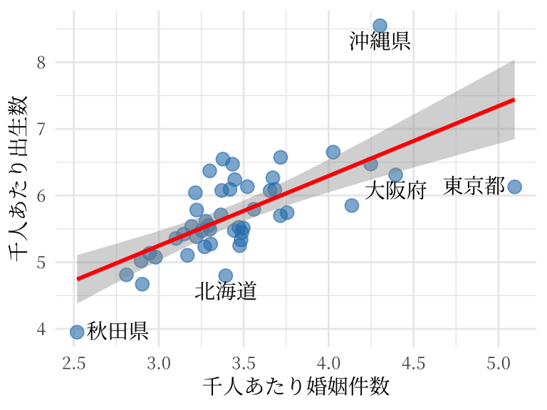

```r
#install.packages("ggrepel")
library(ggrepel)

ggplot(
  data = japan_2023,
  aes(
    x = marriages_per_1000,
    y = births_per_1000
  )
) +
  geom_point(
    size = 3,
    color = "#2C7FB8",
    alpha = 0.6 # 透明
  ) +
  geom_text_repel(
    data = japan_2023 %>%
    filter(prefecture %in% c("東京都", "大阪府", "北海道", "沖縄県", "秋田県")),
    aes(label = prefecture),
    family = "notojp",
    vjust = -0.5
  ) +
  geom_smooth(method = "lm", se = TRUE, color = "red") +
  labs(
    x = "千人あたり婚姻件数",
    y = "千人あたり出生数"
  ) +
  theme_minimal(base_family = "notojp")
```

`method = "lm"` は線形回帰の直線を引くという意味である。`se = TRUE` は信頼区間を表示するという指定である。

## 2.3 折れ線グラフ

折れ線グラフは、時間の変化を見るためによく使われる（全年度のデータを使う）。ここでは、首都圏の出生率推移を見てみよう。

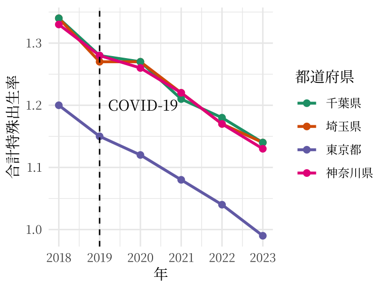

```r
tfr_trend <- japan %>%
  filter(prefecture %in% c("東京都", "神奈川県", "千葉県", "埼玉県"))

ggplot(
  data = tfr_trend,
  aes(
    x = year,
    y = total_fertility_rate,
    color = prefecture
  )
) +
  geom_line(linewidth = 1) +
  geom_point(size = 2) +
  # 縦の点線
  geom_vline(
    xintercept = 2019,
    linetype = "dashed",
    color = "black"
  ) +
  annotate(
  "text",
  x = 2019,
  y = 1.2,
  label = "COVID-19",
  hjust = -0.12,
  ) +
  scale_color_brewer(palette = "Dark2") + # 色のシリーズを変更できる
  labs(
    x = "年",
    y = "合計特殊出生率",
    color = "都道府県"
  ) +
  theme_minimal(base_family = "notojp")
```

時系列データでは、横軸に時間、縦軸に数値を置くのが基本である。

## 2.4 棒グラフ

棒グラフは、カテゴリごとの値を比較するために使う。ここでは、2023年の人口が多い都道府県を確認する。

```r
pop_top10 <- japan_2023 %>%
  arrange(desc(population)) %>%
  slice(1:10)

pop_top10
```

集計済みの値を棒グラフにする場合は、`geom_col()` を使う。

[figure not shown]

```r
ggplot(data = pop_top10, aes(x = prefecture, y = population)) +
  geom_col() + # 棒グラフ
  theme_minimal(base_family = "notojp") +
  theme(axis.text.x = element_text(angle = 90, vjust = 0.5, hjust = 1))
```

都道府県名が横軸に並ぶと読みにくいため、`coord_flip()` で横向きの棒グラフにする。

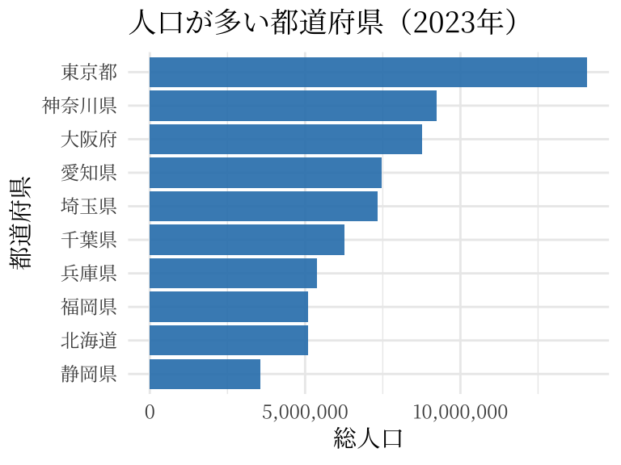

```r
ggplot(
  data = pop_top10,
  aes(
    x = reorder(prefecture, population),
    y = population
  )
) +
  geom_col(
    fill = "#2C7FB8",
    alpha = 0.9
  ) +
  coord_flip() +
  scale_y_continuous(
    labels = scales::comma
  ) +
  labs(
    title = "人口が多い都道府県（2023年）",
    x = "都道府県",
    y = "総人口"
  ) +
  theme_minimal(base_family = "notojp")
```

`reorder(prefecture, population)` は、`population` の値に基づいて都道府県名を並び替えるための指定である。効果的な可視化を行うためには、並び順だけでなく、色、ラベル、軸の表示形式、テーマなどについても適切にカスタマイズする必要がある。

## 2.5 ヒストグラム

ヒストグラムは、1つの数値変数の分布を見るためのグラフである。ここでは、2023年の人口の分布を確認する。人口や財政予算のように桁数の大きい変数では、10万人単位や億円単位に変換するなど、単位を調整すると読みやすくなる。

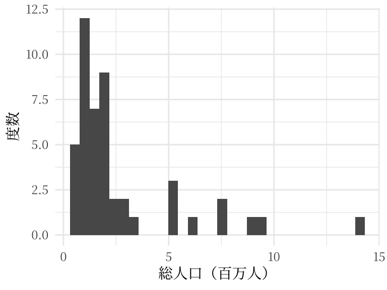

```r
ggplot(data = japan_2023, aes(x = population / 1000000)) +
  geom_histogram() +
  labs(
    x = "総人口（百万人）",
    y = "度数"
  ) +
  theme_minimal(base_family = "notojp")
```

エラーが表示される場合がある。これは、`ggplot2` が自動的に階級幅を決めているためである。通常は、自分で `bins` または `binwidth` を指定した方がよい。

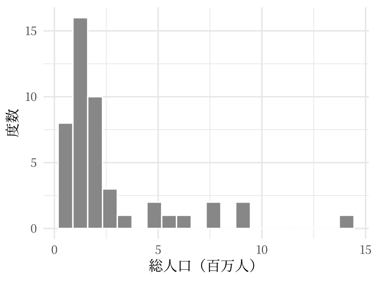

```r
ggplot(data = japan_2023, aes(x = population / 1000000)) +
  geom_histogram(bins = 20, fill = "gray60", color = "white") +
  labs(
    x = "総人口（百万人）",
    y = "度数"
  ) +
  theme_minimal(base_family = "notojp")
```

ヒストグラムを見ると、人口が少ない都道府県が多く、一部の都道府県だけ人口が非常に大きいことがわかる。このように、分布の偏りを確認するにはヒストグラムが便利である。

## 2.6 密度曲線

密度曲線も、数値変数の分布を見るためのグラフである。ヒストグラムよりも滑らかな形で分布を確認できる。

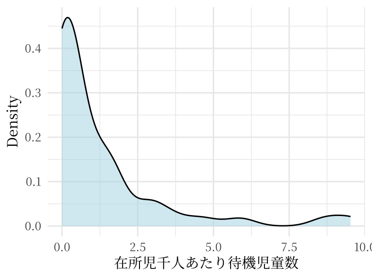

```r
ggplot(data = japan_2023, aes(x = waiting_children_per_1000_nursery_children)) +
  geom_density(fill = "lightblue", alpha = 0.5) +
  labs(
    x = "在所児千人あたり待機児童数",
    y = "Density"
  ) +
  theme_minimal(base_family = "notojp")
```

複数のグループの分布を比較したい場合、`fill` や `color` を使うことができる。複数の分布を同じ図に重ねて表示することで、グループ間の違いを視覚的に比較しやすくなる。一つの図に多くの情報を効率的にまとめられる点も、この手法の利点である。

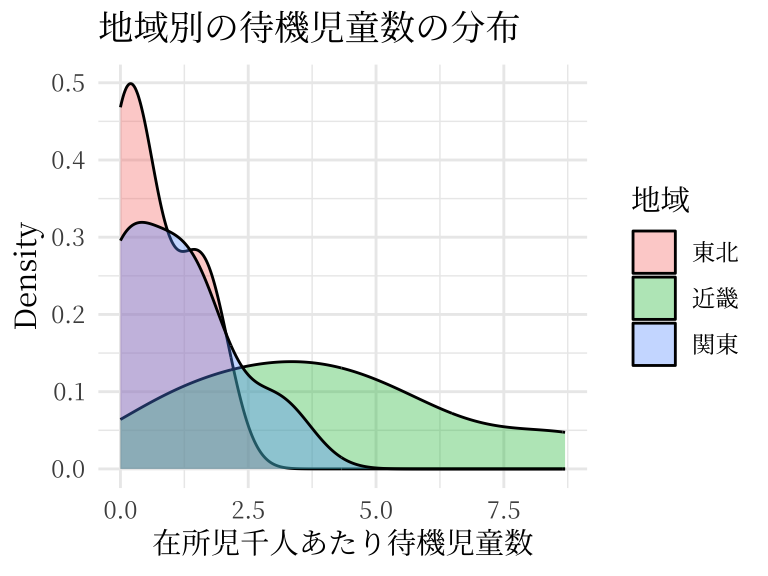

```r
japan_2023 %>%
  filter(region %in% c("関東", "近畿", "東北")) %>%
  ggplot(aes(x = waiting_children_per_1000_nursery_children, fill = region)) +
    geom_density(alpha = 0.35) +
    labs(
      title = "地域別の待機児童数の分布",
      x = "在所児千人あたり待機児童数",
      y = "Density",
      fill = "地域"
    ) +
  　theme_minimal(base_family = "notojp")
```

ただし、グループが多すぎる場合、密度曲線が重なって読みにくくなる。その場合は、箱ひげ図や facet を使う方がよい。

## 2.7 箱ひげ図

箱ひげ図は、グループごとの分布を比較するためのグラフである。中央値、四分位数、外れ値をまとめて確認できる。ここでは、地域ごとに保育所等在所児千人あたり保育士数の分布を比較する。

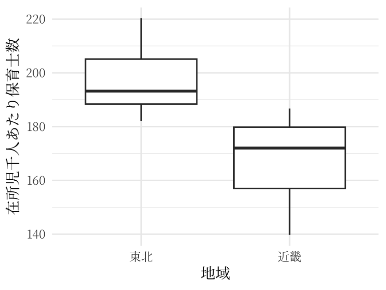

```r
japan_2023 %>%
  filter(region %in% c("近畿", "東北")) %>%
  ggplot(aes(x = region, y = childcare_workers_per_1000_nursery_children)) +
  geom_boxplot() +
  labs(
    x = "地域",
    y = "在所児千人あたり保育士数"
  ) +
  theme_minimal(base_family = "notojp")
```

箱の中央の線は中央値である。箱の上下は第1四分位数と第3四分位数を表す。点は外れ値である。

グループが多くなるとともに、横軸に並ぶと読みにくいため、横向きにする。

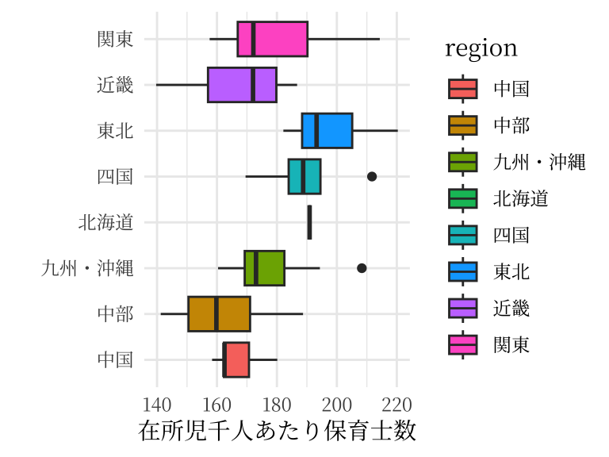

```r
japan_2023 %>%
ggplot(aes(x = region, y = childcare_workers_per_1000_nursery_children, fill = region)) +
  geom_boxplot() +
  coord_flip() +
  labs(
    x = "",
    y = "在所児千人あたり保育士数"
  ) +
  theme_minimal(base_family = "notojp")
```

箱ひげ図は、平均値だけでは見えないばらつきを確認するために便利である。

## 2.8 `facet` による分割

`facet` を使うと、同じ種類のグラフをグループごとに分割して表示できる。

例えば、複数の都道府県について、出生率の推移を同じ形式で比較してみよう。

[figure not shown]

```r
japan %>%
  filter(prefecture %in% c("東京都", "大阪府", "北海道", "沖縄県", "秋田県", "福岡県")) %>%
  ggplot(aes(x = year, y = births_per_1000)) +
    geom_line(color = "steelblue", linewidth = 1) +
    facet_wrap(~ prefecture) +
    theme_minimal(base_family = "notojp") +
    theme(
    axis.text.x = element_text(
      angle = 90
    )
  )
```

`facet_wrap(~ prefecture)` は、`prefecture` ごとに図を分けるという意味である。グループごとの変化を比較したい場合に便利である。

## 2.9 図を保存する

作成した図をファイルとして保存するには、`ggsave()` を使う。

```r
p <- ggplot(data = japan_2023, aes(x = waiting_children_per_1000_nursery_children)) +
  geom_density(fill = "lightblue", alpha = 0.5) +
  labs(
    x = "在所児千人あたり待機児童数",
    y = "Density"
  ) +
  theme_minimal(
    base_family = "notojp",
    base_size = 30)

ggsave(
  filename = "waiting_children.png",
  plot = p,
  width = 6,
  height = 4,
  dpi = 300
)
```

`ggsave()` では、ファイル名、保存する図、幅、高さ、解像度を指定する。レポートやプレゼンで使う場合、`dpi = 300` 程度にするとよい。`base_size` は、図全体の基本フォントサイズを指定する引数である。値を大きくすると、タイトル、軸ラベル、目盛り、凡例などの文字がまとめて大きくなる。発表資料や講義資料では大きめの値を設定すると見やすくなる。

## 2.10 グラフの選び方

どのグラフを使うべきかは、変数の種類と分析目的によって決まる。

| 目的 | 変数 | よく使うグラフ |
| --- | --- | --- |
| 2つの数値変数の関係を見る | 数値 × 数値 | 散布図 |
| 時系列推移 | 時間 × 数値 | 折れ線 |
| カテゴリごとの値を比較する | カテゴリ × 数値 | 棒グラフ |
| 1つの数値変数の分布を見る | 数値 | ヒストグラム、密度曲線 |
| グループごとの分布を比較する | カテゴリ × 数値 | 箱ひげ図 |
| グループごとに同じ図を分ける | カテゴリ× ? | facet |

初心者がよくやる失敗は、図の種類を先に決めてしまうことである。まず**何を見たいのか**を決め、その後で適切なグラフを選ぶべきである。

データ可視化は、自分自身のコードやスタイルを蓄積していく過程である。図の作り方に唯一の正解は存在しない。しかし、一度自分なりのワークフローを構築すれば、それを何度でも再利用することができる。重要なのは毎回異なる図を描くことではなく、効率的かつ再現可能な可視化の流れを標準化することである。

# 3 課題

あなたは、世界的に知られる **データジャーナリスト** である。7月25日の新聞一面トップに掲載する記事として、公開データを用いて社会や経済の動きを伝える短い記事を作成しなさい。

[日経新聞データジャナリスト](https://www.nikkei.co.jp/saiyo/jobs/jobs05.html)  
[イラン戦争の可視化](https://github.com/ztempest0218/iran.git) を参考してみてください。

提出物は、**新聞一面トップ記事としてのデータ可視化レポート**（A4で1～2ページ程度、図は1ページにつき1図程度を目安とする）と、分析に使用した **R Script** とする。締切は7/25 23:59までとする。

提出方法については、7月15日の授業でR Markdownを用いたレポート作成方法を説明した後に案内する。なお、記事作成直前になって慌てないよう、R Scriptは今のうちから少しずつ書き始めておくことを推奨する。

記事のテーマは自由である。ただし、単に図を並べるのではなく、読者に対して「**何が起きているのか**」を説明することを意識する。

1.自分でデータを収集すること。

- SSDSE
- e-Stat
- 政府統計
- スポーツデータ
- 気象データ
- 企業データ
- その他公開データ

などを利用してよい。

2.必要に応じてデータの整理・加工・結合を行うこと。

3.`ggplot2` を用いて複数の図を作成すること。

4.各図について、次の点を説明すること。

- 何を比較しているのか
- なぜその図を作成したのか
- 図から何が読み取れるのか
- データ可視化によって得られる独自の知見があるか

データを使って読者に何かを伝える「短い記事」として構成すること。タイトル、図、説明文が互いに対応していることが望ましい。